# Overview: The vegan package for PCA

```r
library(compbio4all)
```

### Download packages

Only do this once, then comment out of the script. You probably already did this in the previous Code Checkpoint.

```r
# install.packages("ggplot2")
# install.package("vegan")
```

### Load the libraries

```r
library(ggplot2)
library(vegan)
```

### Load the msleep package

The mammals dataset is a classic dataset in the MASS package. msleep is an updated version of the data that includes more numeric data (e.g. hours of sleep) and categorical data (e.g. if a species is endangered)

```r
data(msleep)
```

### Subset numeric variables

msleep has a mixture of numeric and cateogrical varibles. We want only the numeric data and a few key labels, which I’ll also have to set up a special way. Don’t worry about the details

First, all the columns we may want

```r
msleep_num <- msleep[,c("sleep_total","sleep_rem",
                        "sleep_cycle","awake","brainwt" ,
                        "bodywt","vore","order")]
```

All data should be continuous numeric that can take on decimal values, except the last 2

```r
summary(msleep_num[,-c(7:8)])
```

```
##   sleep_total      sleep_rem      sleep_cycle         awake
##  Min.   : 1.90   Min.   :0.100   Min.   :0.1167   Min.   : 4.10
##  1st Qu.: 7.85   1st Qu.:0.900   1st Qu.:0.1833   1st Qu.:10.25
##  Median :10.10   Median :1.500   Median :0.3333   Median :13.90
##  Mean   :10.43   Mean   :1.875   Mean   :0.4396   Mean   :13.57
##  3rd Qu.:13.75   3rd Qu.:2.400   3rd Qu.:0.5792   3rd Qu.:16.15
##  Max.   :19.90   Max.   :6.600   Max.   :1.5000   Max.   :22.10
##                  NA's   :22      NA's   :51
##     brainwt            bodywt
##  Min.   :0.00014   Min.   :   0.005
##  1st Qu.:0.00290   1st Qu.:   0.174
##  Median :0.01240   Median :   1.670
##  Mean   :0.28158   Mean   : 166.136
##  3rd Qu.:0.12550   3rd Qu.:  41.750
##  Max.   :5.71200   Max.   :6654.000
##  NA's   :27
```

We can look at these data with a scatterplot matrix

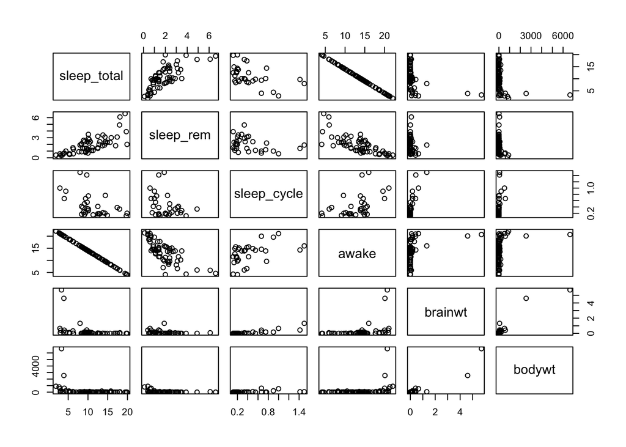

```r
plot(msleep_num[,-c(7:8)])
```

Convert to dataframe

```r
msleep_num <- data.frame(msleep_num)
```

Remove missing values

```r
msleep_num <- na.omit(msleep_num)
```

## Principal components analysis - base R

Principal component analysis is typically done using base R functions.

Run the PCA

```r
pca.out <- prcomp(msleep_num[,-c(7,8)], scale = TRUE)
```

Plot the output

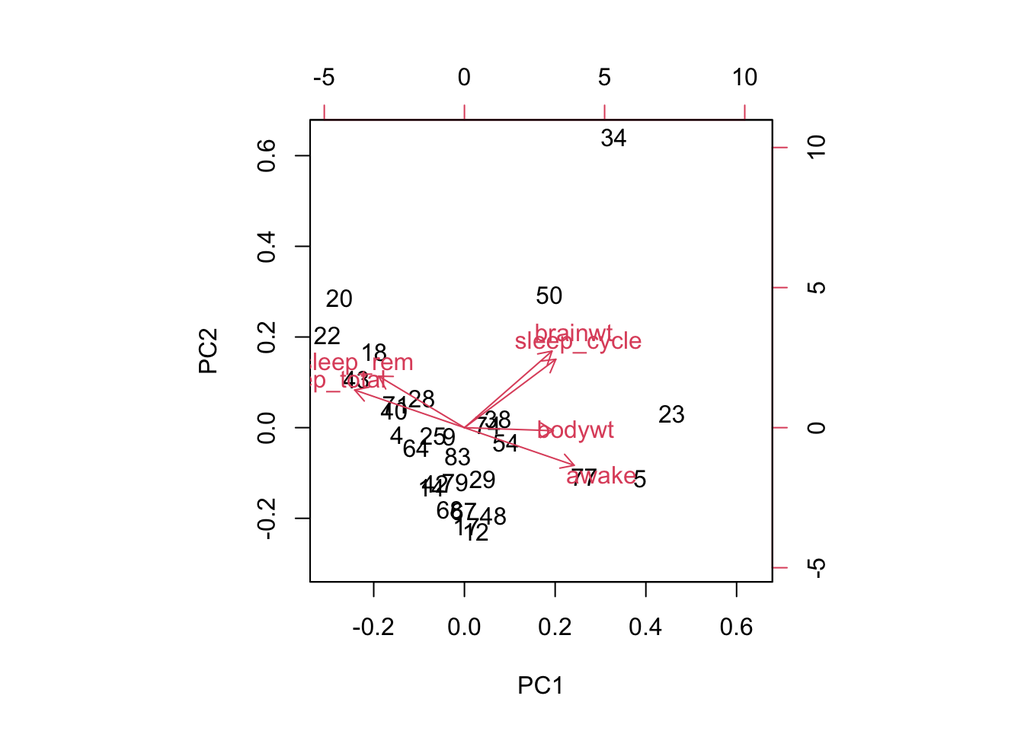

```r
biplot(pca.out)
```

## Principal components analysis - vegan

The base R PCA output isn’t very flexible. The R package vegan is has a function rda() which does PCA and has many more nice features.

For another example see https://rpubs.com/brouwern/veganpca

Run the PCA using rda()

```r
rda.out <- vegan::rda(msleep_num[,-c(7,8)], scale = TRUE)
```

This displays the 2D PCA plot without the arrows. For more info on what this code does, see the RPubs document linked above

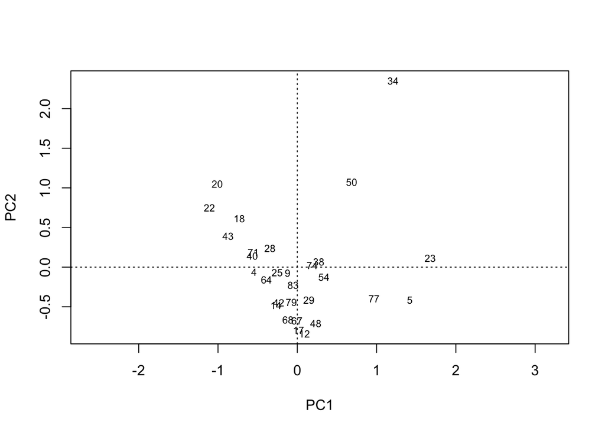

```r
biplot(rda.out, display = "sites")
```

vegan has some nice tools for groups things.

In this dataset I don’t expect there to be any interest groups, but I’ll check anyway. I will supply this code if needed.

PCA is an exploratory method. First I’ll see if there are any groupsing based on diet (“vore”). Not really

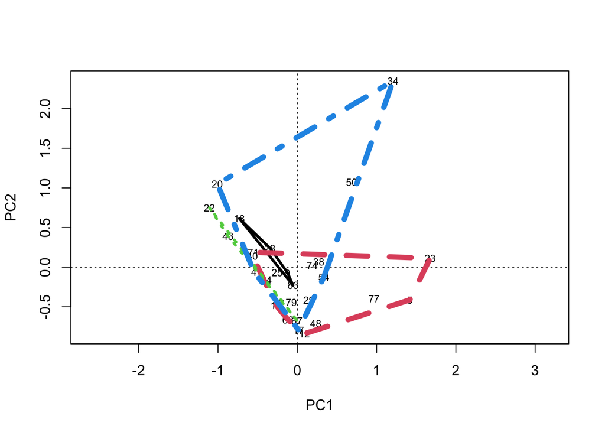

```r
biplot(rda.out, display = "sites")

vegan::ordihull(rda.out,
         group = msleep_num$vore,
         col = 1:7,
         lty = 1:7,
         lwd = c(3,6))
```

## Task

Copy the prevous code chunk and change the group so that the taxonomic order is plotted. Upload the image to this assignment. Consider if there are any meaninginful groups.